# Untilted BLCA Exploration

Charlie Lake (51659233), Carter Glen (16453292), Alvin Hendricks (58104407)

# Data Deconstruction

```r
clinical_data <- read.delim("data/data_clinical_patient.txt", header=TRUE, comment.char="#")
mutation_data <- read.delim("data/data_mutations.txt", header=TRUE)
rna_seq_data <- read.csv("data/RNAseq.csv")
```

```r
head(clinical_data)
```

|  | PATIENT_ID | SUBTYPE | CANCER_TYPE_ACRONYM | OTHER_PATIENT_ID | AGE | SEX | AJCC_PATHOLOGIC_TUMOR_STAGE | AJCC_STAGING_EDITION | DAYS_LAST_FOLLOWUP | DAYS_TO_BIRTH | DAYS_TO_INITIAL_PATHOLOGIC_DIAGNOSIS | ETHNICITY | FORM_COMPLETION_DATE | HISTORY_NEOADJUVANT_TRTYN | ICD_10 | ICD_O_3_HISTOLOGY | ICD_O_3_SITE | INFORMED_CONSENT_VERIFIED | NEW_TUMOR_EVENT_AFTER_INITIAL_TREATMENT | PATH_M_STAGE | PATH_N_STAGE | PATH_T_STAGE | PERSON_NEOPLASM_CANCER_STATUS | PRIMARY_LYMPH_NODE_PRESENTATION_ASSESSMENT | PRIOR_DX | RACE | RADIATION_THERAPY | WEIGHT | CENTER | … |
| --- | --- | --- | --- | --- | --- | --- | --- | --- | --- | --- | --- | --- | --- | --- | --- | --- | --- | --- | --- | --- | --- | --- | --- | --- | --- | --- | --- | --- | --- | --- |
| 1 | TCGA-2F-A9KO | BLCA | BLCA | DD3A6357-9087-44B2-9956-F981E0DE6F1C | 63 | Male | STAGE IV | 6TH | 678 | -23323 | 0 | Not Hispanic Or Latino | 3/19/14 | No | C67.4 | 8120/3 | C67.4 | Yes | Yes | M0 | N1 | T3 | With Tumor | Yes | No | White | No | 65 | Erasmus MC | … |
| 2 | TCGA-2F-A9KP | BLCA | BLCA | 65D1EAEC-28DB-4A41-A4DB-1A710FCB24AD | 66 | Male | STAGE IV | 7TH | NA | -24428 | 0 | Not Hispanic Or Latino | 3/19/14 | No | C67.2 | 8120/3 | C67.2 | Yes | Yes | MX | N2 | T3A | With Tumor | Yes | No | White | No | 130 | Erasmus MC | … |
| 3 | TCGA-2F-A9KQ | BLCA | BLCA | 25EAF3F9-C364-423C-AAAE-925E7B393AFC | 69 | Male | STAGE III | 6TH | 2886 | -25259 | 0 | Not Hispanic Or Latino | 3/19/14 | No | C67.9 | 8120/3 | C67.9 | Yes | No | M0 | N0 | T3A | Tumor Free | Yes | No | White | No | 72 | Erasmus MC | … |
| 4 | TCGA-2F-A9KR | BLCA | BLCA | F6D916B0-8E4C-49CB-A0D4-883908F3284F | 59 | Female | STAGE III | 5TH | 3148 | -21848 | 0 |  | 3/19/14 | No | C67.9 | 8130/3 | C67.9 | Yes | Yes | M0 | N0 | T3A | With Tumor | Yes | No |  | No | 80 | Erasmus MC | … |
| 5 | TCGA-2F-A9KT | BLCA | BLCA | BC6C516B-591E-4950-B6B0-DECAFA666F4E | 83 | Male | STAGE II | 6TH | 3314 | -30520 | 0 | Not Hispanic Or Latino | 3/19/14 | No | C67.4 | 8120/3 | C67.4 | Yes | No | M0 | N0 | T2B | Tumor Free | Yes | Yes | White | No | 80 | Erasmus MC | … |
| 6 | TCGA-2F-A9KW | BLCA | BLCA | 3B464065-B2E9-4FB2-A7DA-09E963FD43B3 | 67 | Female | STAGE III | 7TH | 147 | -24703 | 0 | Not Hispanic Or Latino | 3/19/14 | No | C67.9 | 8120/3 | C67.9 | Yes | Yes | MX | N0 | T3B | With Tumor | Yes | No | White | No | 70 | Erasmus MC | … |

```r
head(mutation_data)
```

|  | Hugo_Symbol | Entrez_Gene_Id | Center | NCBI_Build | Chromosome | Start_Position | End_Position | Strand | Consequence | Variant_Classification | Variant_Type | Reference_Allele | Tumor_Seq_Allele1 | Tumor_Seq_Allele2 | dbSNP_RS | dbSNP_Val_Status | Tumor_Sample_Barcode | Matched_Norm_Sample_Barcode | Match_Norm_Seq_Allele1 | Match_Norm_Seq_Allele2 | Tumor_Validation_Allele1 | Tumor_Validation_Allele2 | Match_Norm_Validation_Allele1 | Match_Norm_Validation_Allele2 | Verification_Status | Validation_Status | Mutation_Status | Sequencing_Phase | Sequence_Source | … |
| --- | --- | --- | --- | --- | --- | --- | --- | --- | --- | --- | --- | --- | --- | --- | --- | --- | --- | --- | --- | --- | --- | --- | --- | --- | --- | --- | --- | --- | --- | --- |
| 1 | DNMBP | 0 | . | GRCh37 | 10 | 101715548 | 101715548 | + | synonymous_variant | Silent | SNP | C | C | T | rs745790586 | . | TCGA-2F-A9KO-01 | TCGA-2F-A9KO-11 | C | C | . | . | . | . | . | . | . | . | . | … |
| 2 | KAZALD1 | 0 | . | GRCh37 | 10 | 102822569 | 102822569 | + | missense_variant | Missense_Mutation | SNP | G | G | A | novel | . | TCGA-2F-A9KO-01 | TCGA-2F-A9KO-11 | G | G | . | . | . | . | . | . | . | . | . | … |
| 3 | HPS6 | 0 | . | GRCh37 | 10 | 103826020 | 103826020 | + | synonymous_variant | Silent | SNP | C | C | T | novel | . | TCGA-2F-A9KO-01 | TCGA-2F-A9KO-11 | C | C | . | . | . | . | . | . | . | . | . | … |
| 4 | NFKB2 | 0 | . | GRCh37 | 10 | 104160055 | 104160055 | + | synonymous_variant | Silent | SNP | G | G | C | novel | . | TCGA-2F-A9KO-01 | TCGA-2F-A9KO-11 | G | G | . | . | . | . | . | . | . | . | . | … |
| 5 | PDCD11 | 0 | . | GRCh37 | 10 | 105200108 | 105200108 | + | missense_variant | Missense_Mutation | SNP | G | G | C | novel | . | TCGA-2F-A9KO-01 | TCGA-2F-A9KO-11 | G | G | . | . | . | . | . | . | . | . | . | … |
| 6 | KIAA1598 | 0 | . | GRCh37 | 10 | 118666167 | 118666167 | + | missense_variant | Missense_Mutation | SNP | C | C | T | novel | . | TCGA-2F-A9KO-01 | TCGA-2F-A9KO-11 | C | C | . | . | . | . | . | . | . | . | . | … |

```r
head(rna_seq_data)
```

|  | X | TCGA.GU.A767.01A.11R.A32O.07 | TCGA.FD.A3B3.01A.12R.A206.07 | TCGA.C4.A0F7.01A.11R.A084.07 | TCGA.DK.A2I1.01A.11R.A180.07 | TCGA.DK.A1AG.01A.11R.A13Y.07 | TCGA.UY.A9PB.01A.11R.A38B.07 | TCGA.ZF.AA54.01A.11R.A39I.07 | TCGA.XF.AAN0.01A.11R.A42T.07 | TCGA.XF.A9SK.01A.11R.A42T.07 | TCGA.FJ.A871.01A.11R.A352.07 | TCGA.ZF.A9R1.01A.11R.A39I.07 | TCGA.FD.A3SM.01A.11R.A22U.07 | TCGA.ZF.A9R2.01A.11R.A39I.07 | TCGA.CF.A47W.01A.11R.A23W.07 | TCGA.ZF.AA4U.01A.11R.A38B.07 | TCGA.DK.A1AD.01A.11R.A13Y.07 | TCGA.E7.A8O7.01A.11R.A36F.07 | TCGA.ZF.AA56.01A.31R.A39I.07 | TCGA.FD.A62P.01A.32R.A30C.07 | TCGA.G2.AA3C.01A.21R.A39I.07 | TCGA.BL.A13I.01A.11R.A277.07 | TCGA.BT.A42C.01A.11R.A23N.07 | TCGA.FD.A5BX.01A.11R.A26T.07 | TCGA.BT.A20Q.11A.11R.A14Y.07 | TCGA.FD.A62S.01A.11R.A30C.07 | TCGA.DK.A6B1.01A.12R.A30C.07 | TCGA.C4.A0F0.01A.12R.A10U.07 | TCGA.DK.A1A3.01A.11R.A13Y.07 | … |
| --- | --- | --- | --- | --- | --- | --- | --- | --- | --- | --- | --- | --- | --- | --- | --- | --- | --- | --- | --- | --- | --- | --- | --- | --- | --- | --- | --- | --- | --- | --- |
| 1 | ENSG00000000003 | 24364 | 3317 | 5461 | 12519 | 7452 | 2689 | 1506 | 2306 | 2837 | 2297 | 6408 | 3541 | 5713 | 4371 | 7128 | 28095 | 9719 | 3088 | 4058 | 929 | 43 | 5418 | 4384 | 197 | 1487 | 15698 | 2690 | 4860 | … |
| 2 | ENSG00000000005 | 58 | 8 | 2 | 0 | 3 | 0 | 0 | 3 | 2 | 0 | 1 | 0 | 2 | 3 | 0 | 7 | 0 | 0 | 1 | 2 | 0 | 3 | 3 | 9 | 3 | 8 | 0 | 1 | … |
| 3 | ENSG00000000419 | 1738 | 3297 | 7192 | 2547 | 2081 | 2517 | 2125 | 2282 | 3354 | 1717 | 2778 | 1461 | 2063 | 1393 | 2782 | 2963 | 2070 | 1615 | 1681 | 892 | 22 | 4550 | 1059 | 699 | 2479 | 2664 | 2970 | 1499 | … |
| 4 | ENSG00000000457 | 491 | 696 | 1178 | 1087 | 1175 | 500 | 358 | 1198 | 782 | 417 | 961 | 1109 | 861 | 589 | 1000 | 1600 | 1755 | 729 | 528 | 233 | 37 | 2013 | 276 | 401 | 607 | 846 | 321 | 670 | … |
| 5 | ENSG00000000460 | 257 | 1226 | 1992 | 752 | 313 | 409 | 555 | 996 | 280 | 382 | 504 | 467 | 423 | 223 | 366 | 2258 | 406 | 574 | 580 | 303 | 36 | 1176 | 127 | 58 | 715 | 726 | 715 | 522 | … |
| 6 | ENSG00000000938 | 284 | 1911 | 167 | 529 | 1770 | 780 | 355 | 647 | 376 | 43 | 625 | 229 | 170 | 401 | 394 | 197 | 1070 | 614 | 772 | 887 | 20 | 1339 | 856 | 76 | 957 | 176 | 134 | 261 | … |

How many people of each sex (who have this cancer) do we have in our data?

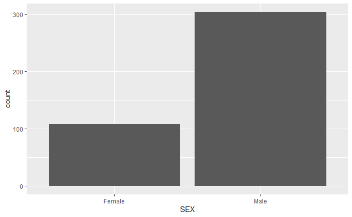

```r
ggplot(clinical_data, aes(x=SEX))+ geom_bar()
```

How about ages?

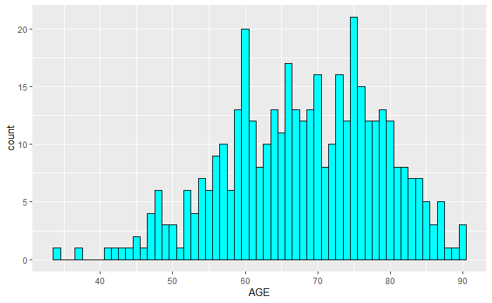

```r
ggplot(clinical_data, aes(x=AGE))+ geom_histogram(binwidth=1, colour="black", fill="cyan")
```

Let us update some values for better processing…

Here, we made sex into a binary value - Male (1), Female (0)

```r
clinical_data$SEX <- ifelse(clinical_data$SEX == 'Male', 1, 0)

# Define function to convert stage of cancer to numeric value
convert_decimal_stage <- function(string){
  if(isEmpty(string)){
    return(0)
  }

  split <- unlist(strsplit(string, " "))
  return(as.numeric(as.roman(split[2])))
}

# Apply change to numeric
clinical_data$AJCC_PATHOLOGIC_TUMOR_STAGE <- unlist(lapply(clinical_data$AJCC_PATHOLOGIC_TUMOR_STAGE, convert_decimal_stage))
length(which(!is.na(clinical_data$AJCC_PATHOLOGIC_TUMOR_STAGE)))
```

```
[1] 409
```

```r
length(which(is.na(clinical_data$AJCC_PATHOLOGIC_TUMOR_STAGE)))
```

```
[1] 2
```

```r
# Drops samples with incomplete entries (no tumor stage), as we want to explore expression related to tumor stage
clinical_data <- clinical_data[complete.cases(clinical_data$AJCC_PATHOLOGIC_TUMOR_STAGE),]

head(clinical_data)
```

|  | PATIENT_ID | SUBTYPE | CANCER_TYPE_ACRONYM | OTHER_PATIENT_ID | AGE | SEX | AJCC_PATHOLOGIC_TUMOR_STAGE | AJCC_STAGING_EDITION | DAYS_LAST_FOLLOWUP | DAYS_TO_BIRTH | DAYS_TO_INITIAL_PATHOLOGIC_DIAGNOSIS | ETHNICITY | FORM_COMPLETION_DATE | HISTORY_NEOADJUVANT_TRTYN | ICD_10 | ICD_O_3_HISTOLOGY | ICD_O_3_SITE | INFORMED_CONSENT_VERIFIED | NEW_TUMOR_EVENT_AFTER_INITIAL_TREATMENT | PATH_M_STAGE | PATH_N_STAGE | PATH_T_STAGE | PERSON_NEOPLASM_CANCER_STATUS | PRIMARY_LYMPH_NODE_PRESENTATION_ASSESSMENT | PRIOR_DX | RACE | RADIATION_THERAPY | WEIGHT | CENTER | … |
| --- | --- | --- | --- | --- | --- | --- | --- | --- | --- | --- | --- | --- | --- | --- | --- | --- | --- | --- | --- | --- | --- | --- | --- | --- | --- | --- | --- | --- | --- | --- |
| 1 | TCGA-2F-A9KO | BLCA | BLCA | DD3A6357-9087-44B2-9956-F981E0DE6F1C | 63 | 1 | 4 | 6TH | 678 | -23323 | 0 | Not Hispanic Or Latino | 3/19/14 | No | C67.4 | 8120/3 | C67.4 | Yes | Yes | M0 | N1 | T3 | With Tumor | Yes | No | White | No | 65 | Erasmus MC | … |
| 2 | TCGA-2F-A9KP | BLCA | BLCA | 65D1EAEC-28DB-4A41-A4DB-1A710FCB24AD | 66 | 1 | 4 | 7TH | NA | -24428 | 0 | Not Hispanic Or Latino | 3/19/14 | No | C67.2 | 8120/3 | C67.2 | Yes | Yes | MX | N2 | T3A | With Tumor | Yes | No | White | No | 130 | Erasmus MC | … |
| 3 | TCGA-2F-A9KQ | BLCA | BLCA | 25EAF3F9-C364-423C-AAAE-925E7B393AFC | 69 | 1 | 3 | 6TH | 2886 | -25259 | 0 | Not Hispanic Or Latino | 3/19/14 | No | C67.9 | 8120/3 | C67.9 | Yes | No | M0 | N0 | T3A | Tumor Free | Yes | No | White | No | 72 | Erasmus MC | … |
| 4 | TCGA-2F-A9KR | BLCA | BLCA | F6D916B0-8E4C-49CB-A0D4-883908F3284F | 59 | 0 | 3 | 5TH | 3148 | -21848 | 0 |  | 3/19/14 | No | C67.9 | 8130/3 | C67.9 | Yes | Yes | M0 | N0 | T3A | With Tumor | Yes | No |  | No | 80 | Erasmus MC | … |
| 5 | TCGA-2F-A9KT | BLCA | BLCA | BC6C516B-591E-4950-B6B0-DECAFA666F4E | 83 | 1 | 2 | 6TH | 3314 | -30520 | 0 | Not Hispanic Or Latino | 3/19/14 | No | C67.4 | 8120/3 | C67.4 | Yes | No | M0 | N0 | T2B | Tumor Free | Yes | Yes | White | No | 80 | Erasmus MC | … |
| 6 | TCGA-2F-A9KW | BLCA | BLCA | 3B464065-B2E9-4FB2-A7DA-09E963FD43B3 | 67 | 0 | 3 | 7TH | 147 | -24703 | 0 | Not Hispanic Or Latino | 3/19/14 | No | C67.9 | 8120/3 | C67.9 | Yes | Yes | MX | N0 | T3B | With Tumor | Yes | No | White | No | 70 | Erasmus MC | … |

Proportion of tumor stages in our data:

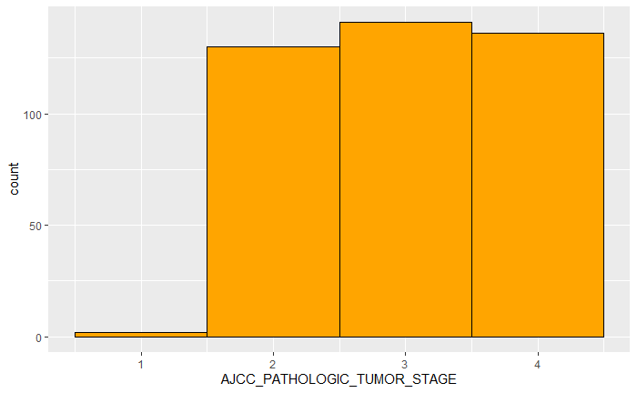

```r
ggplot(clinical_data, aes(x=AJCC_PATHOLOGIC_TUMOR_STAGE))+ geom_histogram(binwidth=1, colour="black", fill="orange")
```

## Matching Patient IDs to RNA-Seq IDs

```r
get_patient_ID <- function(string){
  split <- unlist(strsplit(string,split="[.-]"))
  return(split[3])
}
rseq_headers <- colnames(rna_seq_data)

rseq_patients <- unlist(lapply(rseq_headers[-1],get_patient_ID))
clinical_patients <- unlist(lapply(clinical_data$PATIENT_ID, get_patient_ID))

check_in <- function(string, arr){
  #return(ifelse(string %in% arr == TRUE, 1,0))
  return(match(string,arr))
}

ids_idx <- unlist(lapply(clinical_patients, check_in, arr=rseq_patients))

cat('Number of Valid Entries=',length(ids_idx[!is.na(ids_idx)]),'\nNumber of Invalid Entries=',length(ids_idx[is.na(ids_idx)]),'\nIndex of Invalid Entries =',which(is.na(ids_idx)))
```

```
Number of Valid Entries= 405
Number of Invalid Entries= 4
Index of Invalid Entries = 49 330 353 390
```

# Match RNA_SEQ IDs to Patients IDs

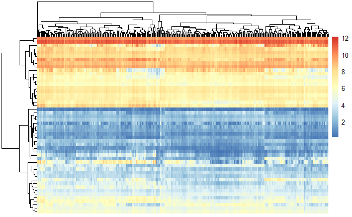

```r
# First, let's filter out genes with a low average expression (mean less than 5), as these will likely not significantly contribute to our analysis
# Only keep genes with a mean expression greater than or equal to 5
filtered_rna_seq_data <- cleaned_rna_seq_data[rowMeans(cleaned_rna_seq_data) >= 5,]

# Then, let's plot it
log_TPM_plusone <- log(filtered_rna_seq_data + 1)

# Our data is too large to cluster all of it - let's cluster into fewer groups so we can visualize general clusters that may exist in the data. This will let us see any groups of high expression (so we know them exist ahead of time!)
pheatmap(log_TPM_plusone, kmeans_k = 50, show_colnames = FALSE, show_rownames = FALSE)
```

```r
gene_ids <- mapIds(org.Hs.eg.db,keys=row.names(cleaned_rna_seq_data), column="SYMBOL",keytype="ENSEMBL",multiVals="first")
# mart <- useMart(biomart = "ensembl", dataset = "hsapiens_gene_ensembl")
#
# gene_ids <- getBM(attributes = "hgnc_symbol",
#                   filters = "ensembl_gene_id", values = rownames(cleaned_rna_seq_data), mart = mart,uniqueRows = FALSE)
```

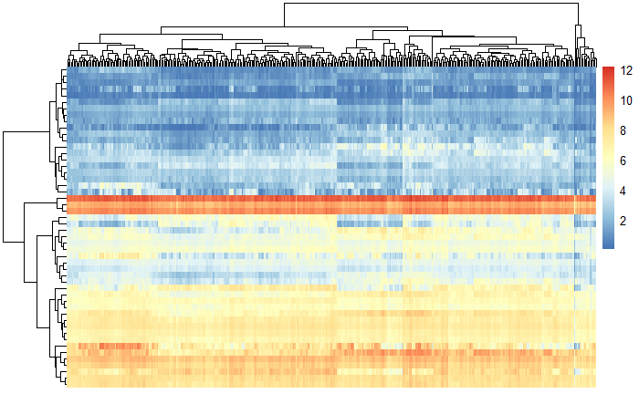

```r
# First, let's filter out genes with a low average expression (mean less than 5), as these will likely not significantly contribute to our analysis
filtered_rna_seq_data <- cleaned_rna_seq_data[rowMeans(cleaned_rna_seq_data) >= 5,]

# take log(TPM + 1) to make it easier to plot as a heatmap, so we can identify expression better
log_TPM_plusone <- log(filtered_rna_seq_data + 1)

# Transpose to set gene counts as features, samples as rows - for use in PCA
Tfiltered_rna_seq_data <- as.data.frame(t(filtered_rna_seq_data))
Tlog_TPM_plusone <- as.data.frame(t(log_TPM_plusone))

# Now, visualize it:
pheatmap(log_TPM_plusone, kmeans_k = 50, show_colnames = FALSE, show_rownames = FALSE)
```

Note that the size of our data is too large to be directly plotted - above we clustered the data on the heatmap into fewer groups of genes so we can visualize general clusters that may exist in the data. This will let us see any groups of genes exist with high expression (so we know them exist ahead of time!). However, we cannot identify specific genes with differential expression due to this.

So, there are clearly groups of genes with high expression. Note that the rows here represent a group of genes (clustered with kmeans; k = 50).

Let’s also look at the z-score transformed version, to see if these groups (or any groups) are actually outlier groups (so just another visualization!):

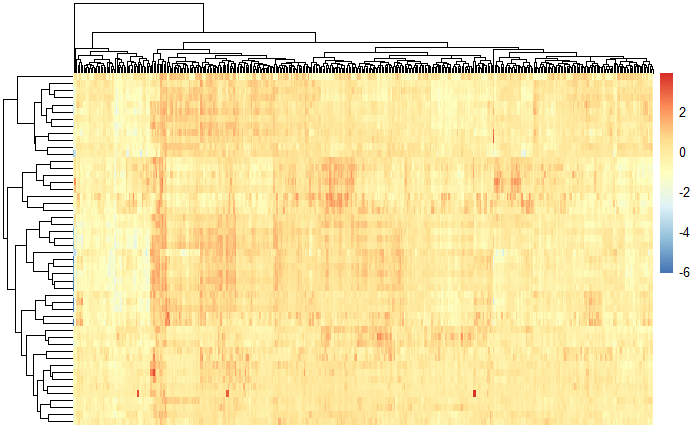

```r
# Transpose so that we scale rows (i.e., expression of a specific gene)
TZTPM <- scale(Tlog_TPM_plusone, scale = TRUE, center = TRUE)
ZTPM <- as.data.frame(t(TZTPM))
# Transpose back, this will show us our rows as gene expression, columns as samples
pheatmap(ZTPM, kmeans_k = 50, show_colnames = FALSE, show_rownames = FALSE)
```

Again, we can see some groups of genes (rows) with generally high, differential expression (z-score normalizes it so we know they’re differentially expressed rather than some genes simply having higher baseline expression). We can also clearly see some samples (columns) with higher expression across many genes. There’s clearly something causing differential expression in these patients. Let’s try to narrow down what it could be.

While we’re at it, let’s also center the data in our original count matrix

```r
Tcentered_TPM <- as.data.frame(scale(Tfiltered_rna_seq_data, scale = FALSE, center = TRUE))
```

Let’s perform PCA: Ideally, this will let us identify axes which (due to representing more variance in the data), can fully explain differences in the cancer stage. That is, the clusters will be defined by the presence of mutations in certain genes (which the PCs will be representing) that allow us to find clear groups of expression. Our aim would be to map this back to stage of cancer.

```r
# Perform PCA, store into a data frame
pcs <- prcomp(Tlog_TPM_plusone, center = TRUE, scale = FALSE)
PCdata <- as.data.frame(pcs$x)
# And, see summary (though it prints out  alot so it is commented out):
#summary(pcs)
```

Let’s plot the values of our different PCs along the axes of different PCs to try to find clusters. Below are a few examples:

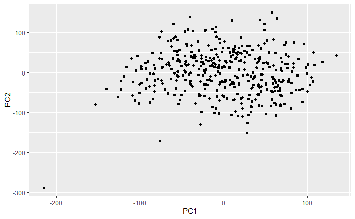

```r
ggplot(PCdata[,1:2], aes(PC1, PC2)) + geom_point()
```

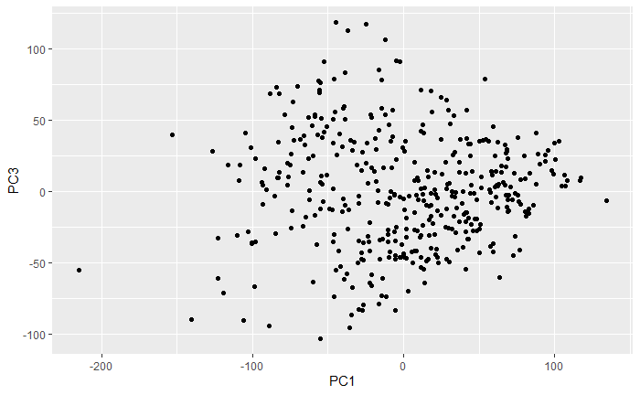

```r
ggplot(PCdata[,c(1,3)], aes(PC1, PC3)) + geom_point()
```

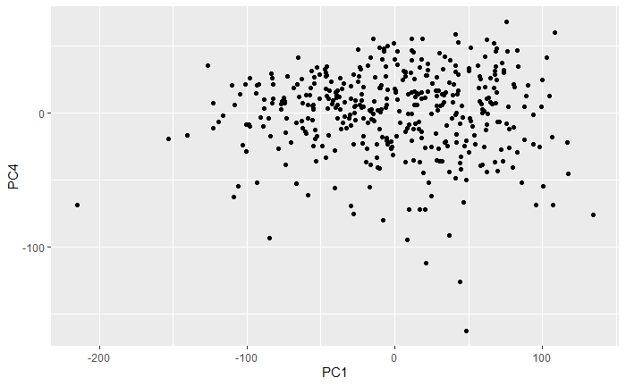

```r
ggplot(PCdata[,c(1,4)], aes(PC1, PC4)) + geom_point()
```

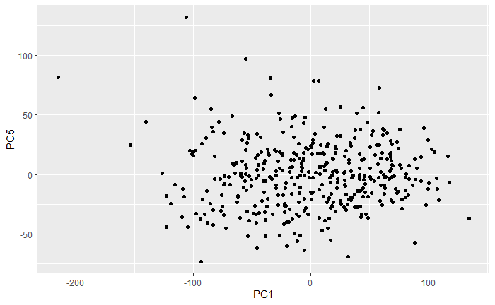

```r
ggplot(PCdata[,c(1,5)], aes(PC1, PC5)) + geom_point()
```

We did not find any explicit perfect separation between groups (in these examples and some others that were tried, excluded as they did not present any new information), and therefore there may not be any linearly separable clusters in the data. Given this, let’s perform clustering on the values of our first two PCs, given that they explain the most variance in expression, and see if there’s any difference in counts. While there may not be perfect separation as we hoped for, we might be able to detect some differences still.

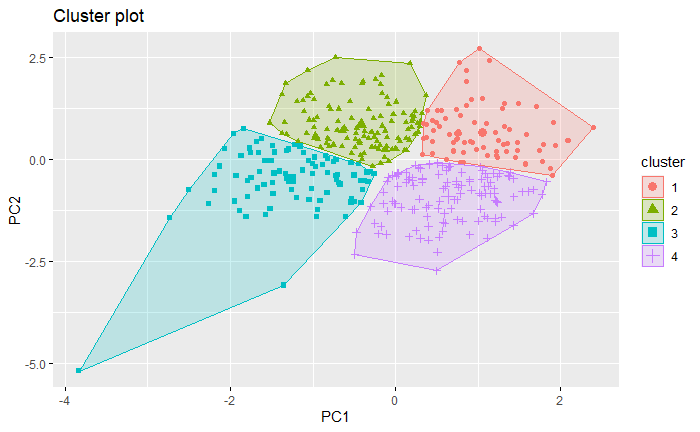

```r
#Run kmeans on first two PCs, and visualize
kmeans_PC_1and2 <- kmeans(PCdata[,1:2], centers = 4, nstart = 50)
fviz_cluster(kmeans_PC_1and2,  data = PCdata[,1:2], geom=c('point'))
```

```r
# Store the cluster centers and labels for our different samples
kmeans_pc_summary <- data.frame(kmeans_PC_1and2$size, kmeans_PC_1and2$centers)
PCdata$cluster <- as.character(kmeans_PC_1and2$cluster)
```

```r
# See summary
kmeans_pc_summary
```

|  | kmeans_PC_1and2.size | PC1 | PC2 |
| --- | --- | --- | --- |
| 1 | 76 | 59.33766 | 37.28179 |
| 2 | 122 | -23.53158 | 46.59078 |
| 3 | 85 | -70.70139 | -27.44403 |
| 4 | 122 | 35.82630 | -50.69466 |

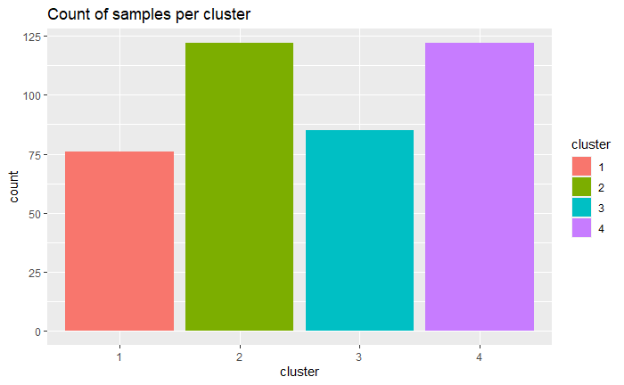

```r
# How many values per cluster?
ggplot(data = PCdata, aes(cluster)) + geom_bar(aes(fill=cluster)) + ggtitle('Count of samples per cluster')
```

Note that this already doesn’t match with our count of cancer stage above - our clusters likely won’t match to the cancer stages.

Perform counts of our clusters to see if these clusters differ in any values.

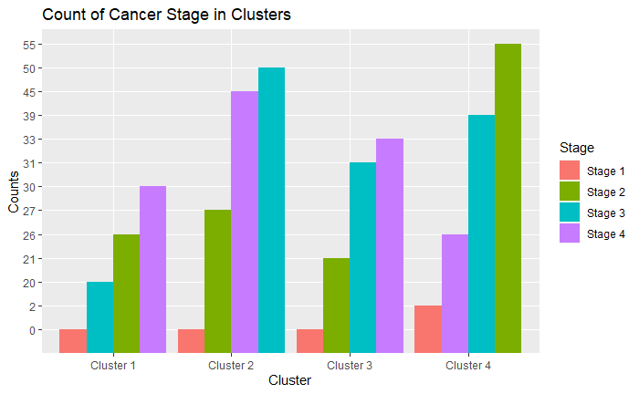

```r
# Subset each cluster from the clinical data
cluster1 <- cleaned_clinical_data[which(PCdata$cluster == 1),]
cluster2 <- cleaned_clinical_data[which(PCdata$cluster == 2),]
cluster3 <- cleaned_clinical_data[which(PCdata$cluster == 3),]
cluster4 <- cleaned_clinical_data[which(PCdata$cluster == 4),]

# Find counts for each of these
c1_1 <- c("Cluster 1", "Stage 1", length(which(cluster1$AJCC_PATHOLOGIC_TUMOR_STAGE == 1)))
c1_2 <- c("Cluster 1", "Stage 2", length(which(cluster1$AJCC_PATHOLOGIC_TUMOR_STAGE == 2)))
c1_3 <- c("Cluster 1", "Stage 3", length(which(cluster1$AJCC_PATHOLOGIC_TUMOR_STAGE == 3)))
c1_4 <- c("Cluster 1", "Stage 4", length(which(cluster1$AJCC_PATHOLOGIC_TUMOR_STAGE == 4)))

c2_1 <- c("Cluster 2", "Stage 1", length(which(cluster2$AJCC_PATHOLOGIC_TUMOR_STAGE == 1)))
c2_2 <- c("Cluster 2", "Stage 2", length(which(cluster2$AJCC_PATHOLOGIC_TUMOR_STAGE == 2)))
c2_3 <- c("Cluster 2", "Stage 3", length(which(cluster2$AJCC_PATHOLOGIC_TUMOR_STAGE == 3)))
c2_4 <- c("Cluster 2", "Stage 4", length(which(cluster2$AJCC_PATHOLOGIC_TUMOR_STAGE == 4)))

c3_1 <- c("Cluster 3", "Stage 1", length(which(cluster3$AJCC_PATHOLOGIC_TUMOR_STAGE == 1)))
c3_2 <- c("Cluster 3", "Stage 2", length(which(cluster3$AJCC_PATHOLOGIC_TUMOR_STAGE == 2)))
c3_3 <- c("Cluster 3", "Stage 3", length(which(cluster3$AJCC_PATHOLOGIC_TUMOR_STAGE == 3)))
c3_4 <- c("Cluster 3", "Stage 4", length(which(cluster3$AJCC_PATHOLOGIC_TUMOR_STAGE == 4)))

c4_1 <- c("Cluster 4", "Stage 1", length(which(cluster4$AJCC_PATHOLOGIC_TUMOR_STAGE == 1)))
c4_2 <- c("Cluster 4", "Stage 2", length(which(cluster4$AJCC_PATHOLOGIC_TUMOR_STAGE == 2)))
c4_3 <- c("Cluster 4", "Stage 3", length(which(cluster4$AJCC_PATHOLOGIC_TUMOR_STAGE == 3)))
c4_4 <- c("Cluster 4", "Stage 4", length(which(cluster4$AJCC_PATHOLOGIC_TUMOR_STAGE == 4)))

# Collect into dataframe
cluster_summary <- t(data.frame(c1_1, c1_2, c1_3, c1_4, c2_1, c2_2, c2_3, c2_4, c3_1, c3_2, c3_3, c3_4, c4_1, c4_2, c4_3, c4_4))
colnames(cluster_summary) <- c('Cluster','Stage','Counts')
cluster_df <- as.data.frame(cluster_summary)

# Plot counts per stage
ggplot() + geom_col(data = cluster_df, aes(x= Cluster, y = Counts, fill = Stage),stat='summary', position='dodge') + ggtitle('Count of Cancer Stage in Clusters')
```

Given that the counts for patients may each have different sequencing depth, running PCA likely won’t allow for us to have clusters accurate to the original data. Let’s try clustering without PCA performed.

Cluster the original data, and once again assume we’ll have 4 groups of separation.

```r
# Cluster, store values
# Use log_TPM_plusone so that genes with a higher baseline expression don't have as much of a higher weighting in distance between points
kmeans_pc <- kmeans(Tlog_TPM_plusone[,1:24769], centers = 4, nstart = 10)
kmeans_pc_summary <- data.frame(kmeans_pc$size, kmeans_pc$centers)
Tlog_TPM_plusone$cluster1 <- as.character(kmeans_pc$cluster)
```

```r
# See summary
kmeans_pc_summary
```

|  | kmeans_pc.size | ENSG00000000003 | ENSG00000000005 | ENSG00000000419 | ENSG00000000457 | ENSG00000000460 | ENSG00000000938 | ENSG00000000971 | ENSG00000001036 | ENSG00000001084 | ENSG00000001167 | ENSG00000001460 | ENSG00000001461 | ENSG00000001497 | ENSG00000001561 | ENSG00000001617 | ENSG00000001626 | ENSG00000001629 | ENSG00000001630 | ENSG00000001631 | ENSG00000002016 | ENSG00000002079 | ENSG00000002330 | ENSG00000002549 | ENSG00000002586 | ENSG00000002587 | ENSG00000002726 | ENSG00000002745 | ENSG00000002746 | … |
| --- | --- | --- | --- | --- | --- | --- | --- | --- | --- | --- | --- | --- | --- | --- | --- | --- | --- | --- | --- | --- | --- | --- | --- | --- | --- | --- | --- | --- | --- | --- |
| 1 | 77 | 7.594795 | 0.9233461 | 7.199086 | 5.957502 | 5.821427 | 5.535144 | 7.306775 | 7.835755 | 7.206177 | 6.905361 | 6.037875 | 6.810310 | 7.596156 | 5.487175 | 7.983531 | 2.033753 | 7.215691 | 4.479293 | 6.454796 | 5.339924 | 2.673424 | 7.399201 | 8.149616 | 8.989645 | 6.123435 | 3.510998 | 2.004610 | 3.669093 | … |
| 2 | 102 | 8.673808 | 1.3926027 | 7.785110 | 6.942894 | 6.578085 | 6.243693 | 8.161221 | 8.261171 | 8.116739 | 7.587310 | 6.921275 | 7.580581 | 7.951932 | 6.833324 | 8.771675 | 3.195027 | 8.095157 | 5.306880 | 7.384342 | 6.074805 | 2.859480 | 7.794803 | 8.462569 | 9.505816 | 7.074648 | 4.836544 | 2.729291 | 4.214130 | … |
| 3 | 143 | 8.915452 | 0.7301799 | 7.556322 | 6.800310 | 6.253100 | 5.747937 | 7.194481 | 8.093542 | 8.434013 | 7.559898 | 6.885335 | 7.436772 | 7.839501 | 6.383419 | 9.324934 | 2.116744 | 7.901517 | 4.868400 | 7.268238 | 6.141449 | 2.423661 | 7.614484 | 7.725658 | 8.680674 | 7.300454 | 4.114385 | 2.187884 | 3.157613 | … |
| 4 | 83 | 7.973242 | 0.4618804 | 7.824604 | 6.533939 | 6.549702 | 6.109551 | 8.111233 | 8.307977 | 8.038962 | 7.449699 | 6.482297 | 7.358754 | 8.114327 | 5.410466 | 8.525335 | 2.098599 | 8.029652 | 5.435556 | 7.244421 | 5.802307 | 4.290966 | 7.693580 | 8.813168 | 9.213771 | 6.932571 | 4.202227 | 3.025769 | 4.546860 | … |

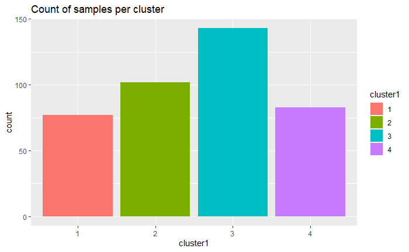

```r
# How many values per cluster?
ggplot(data = Tlog_TPM_plusone, aes(cluster1)) + geom_bar(aes(fill=cluster1)) + ggtitle('Count of samples per cluster')
```

Note that once again, this doesn’t match with our count of cancer stage above - our clusters likely won’t match to the cancer stages unfortunately. But, let’s see counts of cancer stage per cluster to confirm this.

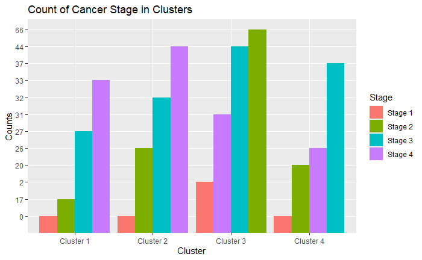

```r
# Subset each cluster from the clinical data
cluster1 <- cleaned_clinical_data[which(Tlog_TPM_plusone$cluster1 == 1),]
cluster2 <- cleaned_clinical_data[which(Tlog_TPM_plusone$cluster1 == 2),]
cluster3 <- cleaned_clinical_data[which(Tlog_TPM_plusone$cluster1 == 3),]
cluster4 <- cleaned_clinical_data[which(Tlog_TPM_plusone$cluster1 == 4),]

# Find counts for each of these
c1_1 <- c("Cluster 1", "Stage 1", length(which(cluster1$AJCC_PATHOLOGIC_TUMOR_STAGE == 1)))
c1_2 <- c("Cluster 1", "Stage 2", length(which(cluster1$AJCC_PATHOLOGIC_TUMOR_STAGE == 2)))
c1_3 <- c("Cluster 1", "Stage 3", length(which(cluster1$AJCC_PATHOLOGIC_TUMOR_STAGE == 3)))
c1_4 <- c("Cluster 1", "Stage 4", length(which(cluster1$AJCC_PATHOLOGIC_TUMOR_STAGE == 4)))

c2_1 <- c("Cluster 2", "Stage 1", length(which(cluster2$AJCC_PATHOLOGIC_TUMOR_STAGE == 1)))
c2_2 <- c("Cluster 2", "Stage 2", length(which(cluster2$AJCC_PATHOLOGIC_TUMOR_STAGE == 2)))
c2_3 <- c("Cluster 2", "Stage 3", length(which(cluster2$AJCC_PATHOLOGIC_TUMOR_STAGE == 3)))
c2_4 <- c("Cluster 2", "Stage 4", length(which(cluster2$AJCC_PATHOLOGIC_TUMOR_STAGE == 4)))

c3_1 <- c("Cluster 3", "Stage 1", length(which(cluster3$AJCC_PATHOLOGIC_TUMOR_STAGE == 1)))
c3_2 <- c("Cluster 3", "Stage 2", length(which(cluster3$AJCC_PATHOLOGIC_TUMOR_STAGE == 2)))
c3_3 <- c("Cluster 3", "Stage 3", length(which(cluster3$AJCC_PATHOLOGIC_TUMOR_STAGE == 3)))
c3_4 <- c("Cluster 3", "Stage 4", length(which(cluster3$AJCC_PATHOLOGIC_TUMOR_STAGE == 4)))

c4_1 <- c("Cluster 4", "Stage 1", length(which(cluster4$AJCC_PATHOLOGIC_TUMOR_STAGE == 1)))
c4_2 <- c("Cluster 4", "Stage 2", length(which(cluster4$AJCC_PATHOLOGIC_TUMOR_STAGE == 2)))
c4_3 <- c("Cluster 4", "Stage 3", length(which(cluster4$AJCC_PATHOLOGIC_TUMOR_STAGE == 3)))
c4_4 <- c("Cluster 4", "Stage 4", length(which(cluster4$AJCC_PATHOLOGIC_TUMOR_STAGE == 4)))

# Collect into dataframe
cluster_summary <- as.data.frame(t(data.frame(c1_1, c1_2, c1_3, c1_4, c2_1, c2_2, c2_3, c2_4, c3_1, c3_2, c3_3, c3_4, c4_1, c4_2, c4_3, c4_4)))
colnames(cluster_summary) <- c('Cluster','Stage','Counts')
cluster_df <- as.data.frame(cluster_summary)

# Plot counts per stage
#ggplot(data = cluster_df, aes(x= Cluster, y = Counts, fill = Stage), ylim(0,70)) + geom_bar(position = "dodge") + ggtitle('Count of Cancer Stage in Clusters')

ggplot() + geom_col(data = cluster_df, aes(x= Cluster, y = Counts, fill = Stage),stat='summary', position='dodge') + ggtitle('Count of Cancer Stage in Clusters')
```

While these results are different than before, there’s no clear mapping of these clusters to our different stages of cancer. So, we can’t use these clusters to narrow down what genes may be causing different stages of cancer.

Let’s re-do the same process and see if we can cluster and find concordance with any other parameters (specifically sex and race).

Next, let’s see if we can find any differences in expression for Race:

Note that clustering is already done - we want to assume there are 4 clusters once again.

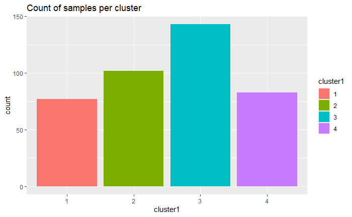

```r
# How many values per cluster?
ggplot(data = Tlog_TPM_plusone, aes(cluster1)) + geom_bar(aes(fill=cluster1)) + ggtitle('Count of samples per cluster')
```

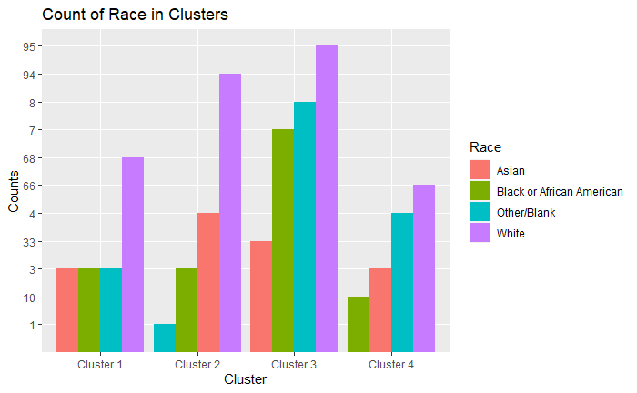

```r
# Subset each cluster from the clinical data
cluster1 <- cleaned_clinical_data[which(Tlog_TPM_plusone$cluster1 == 1),]
cluster2 <- cleaned_clinical_data[which(Tlog_TPM_plusone$cluster1 == 2),]
cluster3 <- cleaned_clinical_data[which(Tlog_TPM_plusone$cluster1 == 3),]
cluster4 <- cleaned_clinical_data[which(Tlog_TPM_plusone$cluster1 == 4),]

# Find counts for each of these
c1_1 <- c("Cluster 1", "Asian", length(which(cluster1$RACE == "Asian")))
c1_2 <- c("Cluster 1", "White", length(which(cluster1$RACE == "White")))
c1_3 <- c("Cluster 1", "Black or African American", length(which(cluster1$RACE == "Black or African American")))
c1_4 <- c("Cluster 1", "Other/Blank", length(which(cluster1$RACE == "")))

c2_1 <- c("Cluster 2", "Asian", length(which(cluster2$RACE == "Asian")))
c2_2 <- c("Cluster 2", "White", length(which(cluster2$RACE == "White")))
c2_3 <- c("Cluster 2", "Black or African American", length(which(cluster2$RACE == "Black or African American")))
c2_4 <- c("Cluster 2", "Other/Blank", length(which(cluster2$RACE == "")))

c3_1 <- c("Cluster 3", "Asian", length(which(cluster3$RACE == "Asian")))
c3_2 <- c("Cluster 3", "White", length(which(cluster3$RACE == "White")))
c3_3 <- c("Cluster 3", "Black or African American", length(which(cluster3$RACE == "Black or African American")))
c3_4 <- c("Cluster 3", "Other/Blank", length(which(cluster3$RACE == "")))

c4_1 <- c("Cluster 4", "Asian", length(which(cluster4$RACE == "Asian")))
c4_2 <- c("Cluster 4", "White", length(which(cluster4$RACE == "White")))
c4_3 <- c("Cluster 4", "Black or African American", length(which(cluster4$RACE == "Black or African American")))
c4_4 <- c("Cluster 4", "Other/Blank", length(which(cluster4$RACE == "")))

# Collect into dataframe
cluster_summary <- as.data.frame(t(data.frame(c1_1, c1_2, c1_3, c1_4, c2_1, c2_2, c2_3, c2_4, c3_1, c3_2, c3_3, c3_4, c4_1, c4_2, c4_3, c4_4)))
colnames(cluster_summary) <- c('Cluster','Race','Counts')
cluster_df <- as.data.frame(cluster_summary)

# Plot counts per stage
ggplot() + geom_col(data = cluster_df, aes(x= Cluster, y = Counts, fill = Race),stat='summary', position='dodge') + ggtitle('Count of Race in Clusters')
```

```r
table(clinical_data$OS_STATUS)
```

[output not shown]

```r
clin_df = cleaned_clinical_data[,
                    c("PATIENT_ID",
                      "DSS_STATUS",
                      "DSS_MONTHS",
                      "DAYS_LAST_FOLLOWUP",
                      "SEX",
                      "AJCC_PATHOLOGIC_TUMOR_STAGE",
                      "RACE",
                      "AGE")]
clin_df$deceased = clin_df$DSS_STATUS == "1:DEAD WITH TUMOR"

clin_df$AJCC_stage = clin_df$AJCC_PATHOLOGIC_TUMOR_STAGE

# create an "overall survival" variable that is equal to days_to_death
# for dead patients, and to days_to_last_follow_up for patients who
# are still alive

clin_df$overall_survival = cleaned_clinical_data$OS_MONTHS*30 #30 days = month

clin_df$race = ifelse(clin_df$RACE == "White" | clin_df$RACE == "Asian", clin_df$RACE, "Other")

clin_df$SEX = ifelse(clin_df$SEX == 0, "Female", "Male")

clin_df$age <- sapply(clin_df$AGE, function(x) {switch(ifelse(x < 60, 0, 1) + ifelse(x < 70, 0, 1) + ifelse(x < 80, 0, 1) + 1, "<60", "60-70", "70-80", "80+")})


# show first 10 samples
head(clin_df)
```

[output not shown]

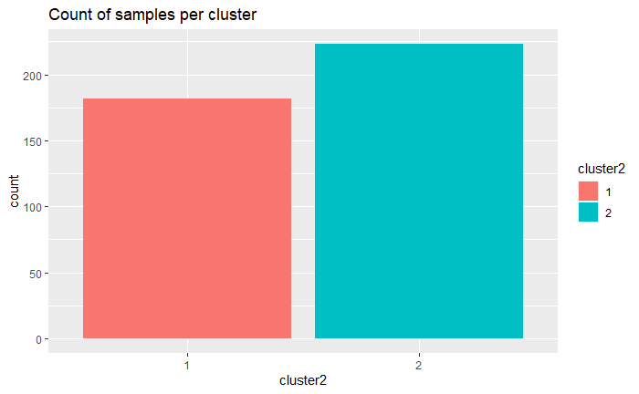

```r
# How many values per cluster?
ggplot(data = Tlog_TPM_plusone, aes(cluster2)) + geom_bar(aes(fill=cluster2)) + ggtitle('Count of samples per cluster')
```

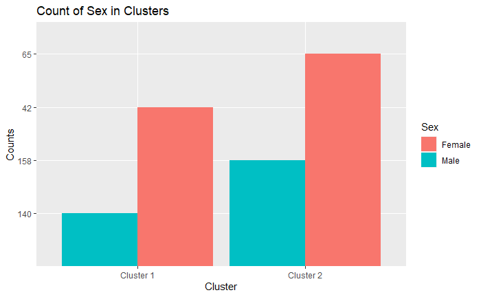

```r
# Subset each cluster from the clinical data
cluster1 <- cleaned_clinical_data[which(Tlog_TPM_plusone$cluster2 == 1),]
cluster2 <- cleaned_clinical_data[which(Tlog_TPM_plusone$cluster2 == 2),]

# Find counts for each of these
c1_1 <- c("Cluster 1", "Female", length(which(cluster1$SEX == 0)))
c1_2 <- c("Cluster 1", "Male", length(which(cluster1$SEX == 1)))

c2_1 <- c("Cluster 2", "Female", length(which(cluster2$SEX == 0)))
c2_2 <- c("Cluster 2", "Male", length(which(cluster2$SEX == 1)))

# Collect into dataframe
cluster_summary <- as.data.frame(t(data.frame(c1_1, c2_1, c1_2, c2_2)))
colnames(cluster_summary) <- c('Cluster','Sex','Counts')
cluster_df <- as.data.frame(cluster_summary)

# Plot counts per stage
ggplot(data = cluster_df, aes(x= Cluster, y = Counts, fill = Sex),stat='summary') + geom_col(position='dodge') + ggtitle('Count of Sex in Clusters')
```

# Survival Analysis

Let’s run survival analysis on each of our clusters

```r
# Do we need this?
#query <- GDCquery(project = "TCGA-BLCA", data.category = "Transcriptome Profiling", data.type = "Gene Expression Quantification", workflow.type = "HTSeq - Counts")
#GDCdownload(query)
#tcga_data <- GDCprepare(query)a
```

```r
table(clinical_data$OS_STATUS)
```

```
  0:LIVING 1:DECEASED
       229        180
```

```r
clin_df = cleaned_clinical_data[,
                    c("PATIENT_ID",
                      "DSS_STATUS",
                      "DSS_MONTHS",
                      "DAYS_LAST_FOLLOWUP",
                      "SEX",
                      "AJCC_PATHOLOGIC_TUMOR_STAGE",
                      "RACE",
                      "AGE")]
clin_df$deceased = clin_df$DSS_STATUS == "1:DEAD WITH TUMOR"

clin_df$AJCC_stage = clin_df$AJCC_PATHOLOGIC_TUMOR_STAGE

# create an "overall survival" variable that is equal to days_to_death
# for dead patients, and to days_to_last_follow_up for patients who
# are still alive

clin_df$overall_survival = cleaned_clinical_data$OS_MONTHS*30 #30 days = month

clin_df$race = ifelse(clin_df$RACE == "White" | clin_df$RACE == "Asian", clin_df$RACE, "Other")

clin_df$SEX = ifelse(clin_df$SEX == 0, "Female", "Male")

clin_df$age <- sapply(clin_df$AGE, function(x) {switch(ifelse(x < 60, 0, 1) + ifelse(x < 70, 0, 1) + ifelse(x < 80, 0, 1) + 1, "<60", "60-70", "70-80", "80+")})

clin_df$cluster1 <- Tlog_TPM_plusone$cluster1

clin_df$cluster2 <- Tlog_TPM_plusone$cluster2

# show first 10 samples
head(clin_df)
```

|  | PATIENT_ID | DSS_STATUS | DSS_MONTHS | DAYS_LAST_FOLLOWUP | SEX | AJCC_PATHOLOGIC_TUMOR_STAGE | RACE | AGE | deceased | AJCC_stage | overall_survival | race | age | cluster1 | cluster2 |
| --- | --- | --- | --- | --- | --- | --- | --- | --- | --- | --- | --- | --- | --- | --- | --- |
| 1 | TCGA-2F-A9KO | 1:DEAD WITH TUMOR | 24.131242 | 678 | Male | 4 | White | 63 | TRUE | 4 | 723.9373 | White | 60-70 | 2 | 2 |
| 2 | TCGA-2F-A9KP | 1:DEAD WITH TUMOR | 11.966992 | NA | Male | 4 | White | 66 | TRUE | 4 | 359.0098 | White | 60-70 | 3 | 1 |
| 3 | TCGA-2F-A9KQ | 0:ALIVE OR DEAD TUMOR FREE | 94.881152 | 2886 | Male | 3 | White | 69 | FALSE | 3 | 2846.4346 | White | 60-70 | 3 | 1 |
| 4 | TCGA-2F-A9KR | 1:DEAD WITH TUMOR | 104.645429 | 3148 | Female | 3 |  | 59 | TRUE | 3 | 3139.3629 | Other | <60 | 3 | 1 |
| 5 | TCGA-2F-A9KT | 0:ALIVE OR DEAD TUMOR FREE | 108.952231 | 3314 | Male | 2 | White | 83 | FALSE | 2 | 3268.5669 | White | 80+ | 3 | 1 |
| 6 | TCGA-2F-A9KW | 1:DEAD WITH TUMOR | 8.350593 | 147 | Female | 3 | White | 67 | TRUE | 3 | 250.5178 | White | 60-70 | 1 | 2 |

The following show overall survival rates for:

Sex

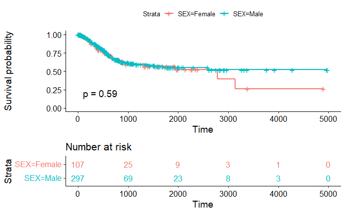

```r
fit = survfit(Surv(overall_survival, deceased) ~ SEX, data = clin_df)
ggsurvplot(fit, data=clin_df, pval=T, risk.table=T, risk.table.col="strata", risk.table.height=0.35)
```

Cancer Stage

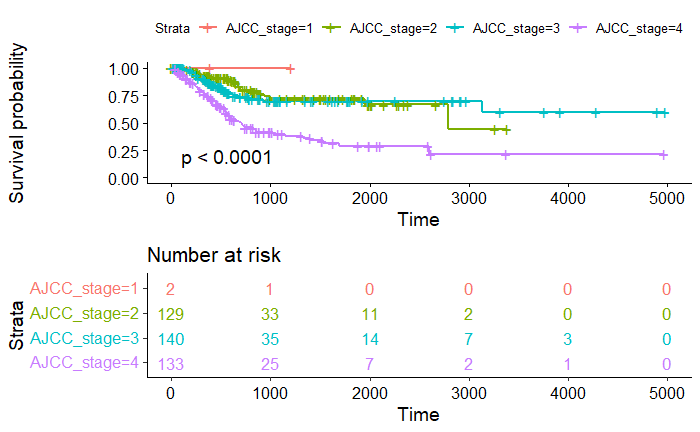

```r
fit = survfit(Surv(overall_survival, deceased) ~ AJCC_stage, data = clin_df)
ggsurvplot(fit, data=clin_df, pval=T, risk.table=T, risk.table.col="strata", risk.table.height=0.45)
```

Race

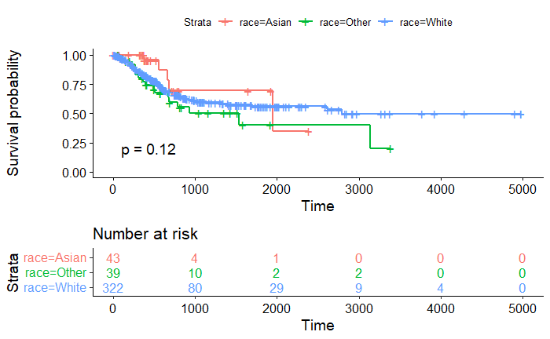

```r
fit = survfit(Surv(overall_survival, deceased) ~ race, data = clin_df)
ggsurvplot(fit, data=clin_df, pval=T,risk.table=T, risk.table.col="strata", risk.table.height=0.35)
```

Age

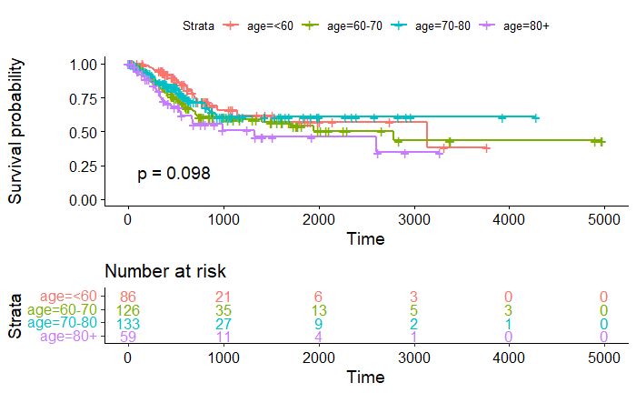

```r
fit = survfit(Surv(overall_survival, deceased) ~ age, data = clin_df)
ggsurvplot(fit, data=clin_df, pval=T,risk.table=T, risk.table.col="strata", risk.table.height=0.35)
```

Now, let’s perform survival analysis for each of our k-means clustering runs to see if we find anything different:

k = 4: Cluster 1

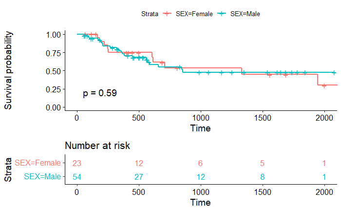

```r
cluster1 <- clin_df[which(Tlog_TPM_plusone$cluster1 == 1),]
fit = survfit(Surv(overall_survival, deceased) ~ SEX, data = cluster1)
ggsurvplot(fit, data=clin_df, pval=T, risk.table=T, risk.table.col="strata", risk.table.height=0.35)
```

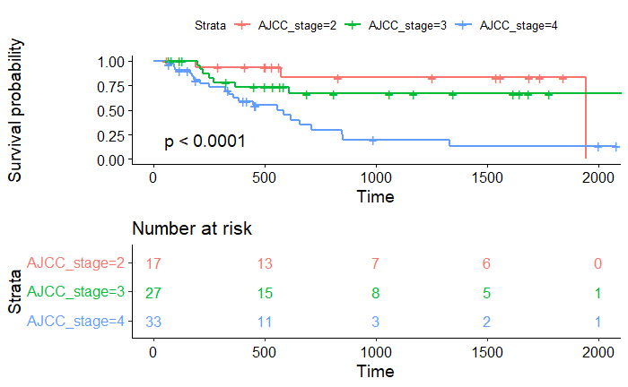

```r
fit = survfit(Surv(overall_survival, deceased) ~ AJCC_stage, data = cluster1)
ggsurvplot(fit, data=clin_df, pval=T, risk.table=T, risk.table.col="strata", risk.table.height=0.45)
```

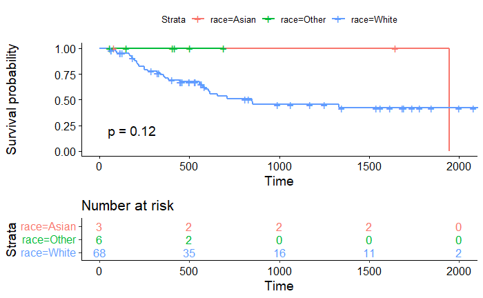

```r
fit = survfit(Surv(overall_survival, deceased) ~ race, data = cluster1)
ggsurvplot(fit, data=clin_df, pval=T,risk.table=T, risk.table.col="strata", risk.table.height=0.35)
```

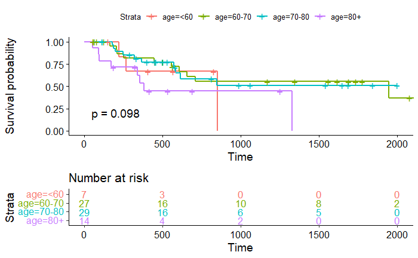

```r
fit = survfit(Surv(overall_survival, deceased) ~ age, data = cluster1)
ggsurvplot(fit, data=clin_df, pval=T,risk.table=T, risk.table.col="strata", risk.table.height=0.35)
```

Cluster 2

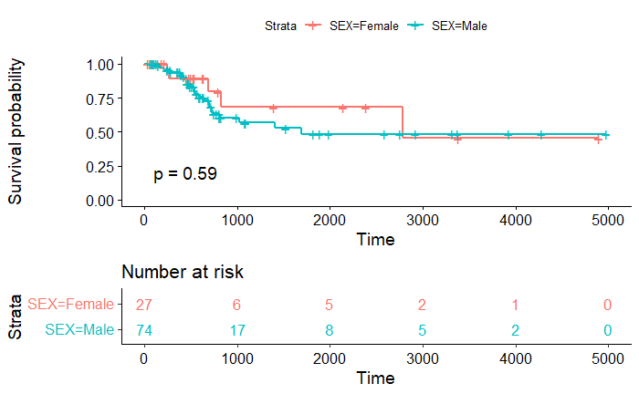

```r
cluster2 <- clin_df[which(Tlog_TPM_plusone$cluster1 == 2),]
fit = survfit(Surv(overall_survival, deceased) ~ SEX, data = cluster2)
ggsurvplot(fit, data=clin_df, pval=T, risk.table=T, risk.table.col="strata", risk.table.height=0.35)
```

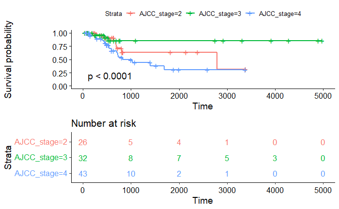

```r
fit = survfit(Surv(overall_survival, deceased) ~ AJCC_stage, data = cluster2)
ggsurvplot(fit, data=clin_df, pval=T, risk.table=T, risk.table.col="strata", risk.table.height=0.45)
```

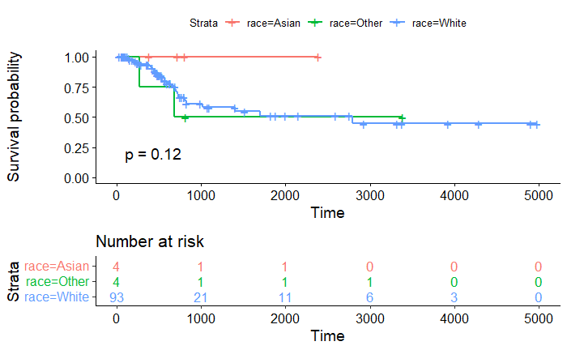

```r
fit = survfit(Surv(overall_survival, deceased) ~ race, data = cluster2)
ggsurvplot(fit, data=clin_df, pval=T,risk.table=T, risk.table.col="strata", risk.table.height=0.35)
```

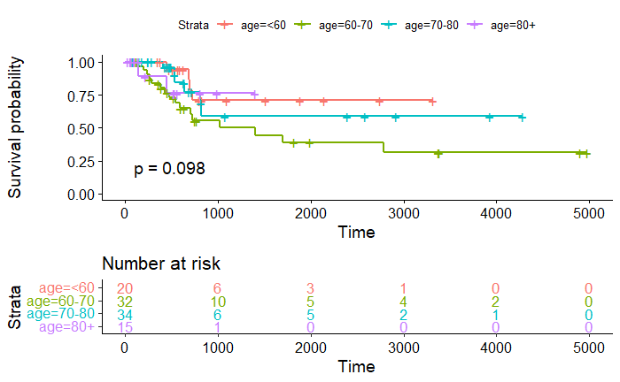

```r
fit = survfit(Surv(overall_survival, deceased) ~ age, data = cluster2)
ggsurvplot(fit, data=clin_df, pval=T,risk.table=T, risk.table.col="strata", risk.table.height=0.35)
```

Cluster 3

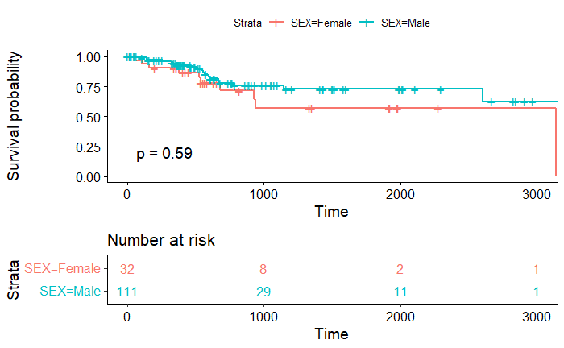

```r
cluster3 <- clin_df[which(Tlog_TPM_plusone$cluster1 == 3),]
fit = survfit(Surv(overall_survival, deceased) ~ SEX, data = cluster3)
ggsurvplot(fit, data=clin_df, pval=T, risk.table=T, risk.table.col="strata", risk.table.height=0.35)
```